# Scholarship Data Exploration

# Basic linear model

Begin with a basic lm with transformed variables.

```r
# Remove unused variables
lmdat <-
  mdat %>% filter(student.gifts > 0) %>% select(-student.gifts, -stewardee, -gift.cap, -first.gift)
# Recenter deg.year
lmdat$deg.year.ctr <- lmdat$deg.year - min(lmdat$deg.year)
# Linear model for donors
lmod <- lm(
  student.gifts.lt ~
    # Low importance
     spouse + sqrt(events.stu) + lead.facil + nice.title + sqrt(scholarship) + stu.supp +
    # Use as-is
    deg.year.ctr + deg.prg + nice.title + fys.recent + nonprofit +
    # Sqrt transform
    sqrt(employ.yrs) + sqrt(fys.giving) + sqrt(af.gifts) + sqrt(known.to) + sqrt(committees) +
    sqrt(vols) + sqrt(speak) + sqrt(stu.acts) + sqrt(events),
  data=lmdat
)

# Model statistics
summary(lmod)
```

```
##
## Call:
## lm(formula = student.gifts.lt ~ spouse + sqrt(events.stu) + lead.facil +
##     nice.title + sqrt(scholarship) + stu.supp + deg.year.ctr +
##     deg.prg + nice.title + fys.recent + nonprofit + sqrt(employ.yrs) +
##     sqrt(fys.giving) + sqrt(af.gifts) + sqrt(known.to) + sqrt(committees) +
##     sqrt(vols) + sqrt(speak) + sqrt(stu.acts) + sqrt(events),
##     data = lmdat)
##
## Residuals:
##     Min      1Q  Median      3Q     Max
## -3.2337 -0.4935 -0.0915  0.3651  3.9536
##
## Coefficients:
##                              Estimate Std. Error t value Pr(>|t|)
## (Intercept)                  2.285511   0.123004  18.581  < 2e-16 ***
## spouseMarried                0.043510   0.036030   1.208  0.22730
## spouseMarried to Booth Alum  0.152916   0.062616   2.442  0.01466 *
## spouseMarried to UC Alum     0.079220   0.097898   0.809  0.41846
## sqrt(events.stu)            -0.068390   0.031490  -2.172  0.02995 *
## lead.facil                  -0.139025   0.080648  -1.724  0.08484 .
## nice.title                   0.228536   0.037293   6.128 1.01e-09 ***
## sqrt(scholarship)            0.007404   0.033365   0.222  0.82440
## stu.supp                    -0.045341   0.185882  -0.244  0.80731
## deg.year.ctr                -0.006679   0.001693  -3.945 8.17e-05 ***
## deg.prgEMBA                  0.138686   0.058514   2.370  0.01785 *
## deg.prgOther                -0.239574   0.815283  -0.294  0.76889
## deg.prgPart-Time            -0.035913   0.041441  -0.867  0.38622
## deg.prgPh.D.                 0.143536   0.147380   0.974  0.33018
## fys.recent                   0.039119   0.013410   2.917  0.00356 **
## nonprofit                    0.719753   0.081623   8.818  < 2e-16 ***
## sqrt(employ.yrs)             0.043642   0.009693   4.502 6.99e-06 ***
## sqrt(fys.giving)            -0.019513   0.022767  -0.857  0.39149
## sqrt(af.gifts)               0.007579   0.029180   0.260  0.79509
## sqrt(known.to)               0.150008   0.017654   8.497  < 2e-16 ***
## sqrt(committees)             0.640485   0.068915   9.294  < 2e-16 ***
## sqrt(vols)                   0.067238   0.022258   3.021  0.00254 **
## sqrt(speak)                  0.253211   0.055353   4.574 4.97e-06 ***
## sqrt(stu.acts)               0.009650   0.027835   0.347  0.72884
## sqrt(events)                 0.063100   0.015352   4.110 4.06e-05 ***
## ---
## Signif. codes:  0 '***' 0.001 '**' 0.01 '*' 0.05 '.' 0.1 ' ' 1
##
## Residual standard error: 0.8101 on 2898 degrees of freedom
## Multiple R-squared:  0.3466, Adjusted R-squared:  0.3412
## F-statistic: 64.07 on 24 and 2898 DF,  p-value: < 2.2e-16
```

Adjusted $r^2$ of .34 actually seems high to me for a first pass. Among the covariates, `deg.year` and the various engagement indicators are the most interesting. The factors `nice.title` and `nonprofit` are as expected. Before thinking about removing variables, check the diagnostic plots.

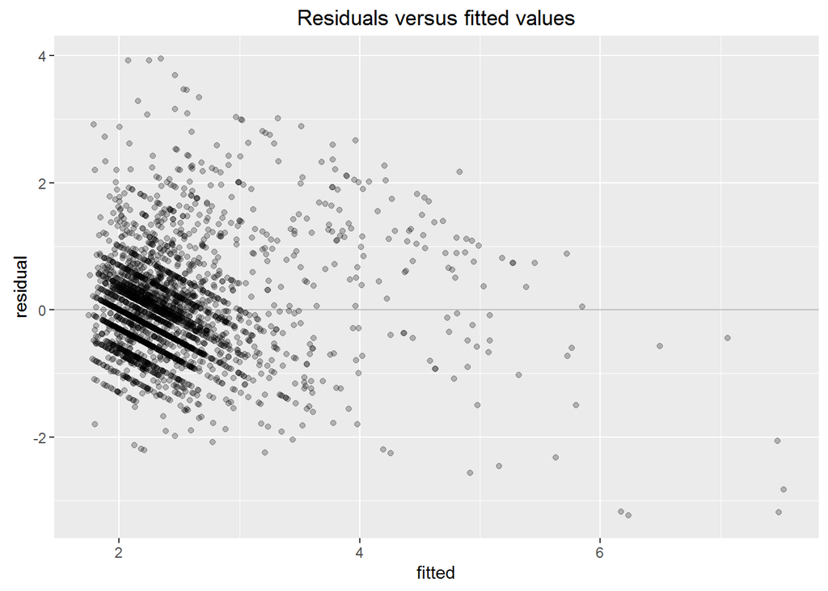

Nonlinearity is apparent as a result of the skewness in `student.gifts`, even after log transformation. There’s a bit of unequal variance as well. Taking a more aggressive transformation might help but would make the model less interpretable.

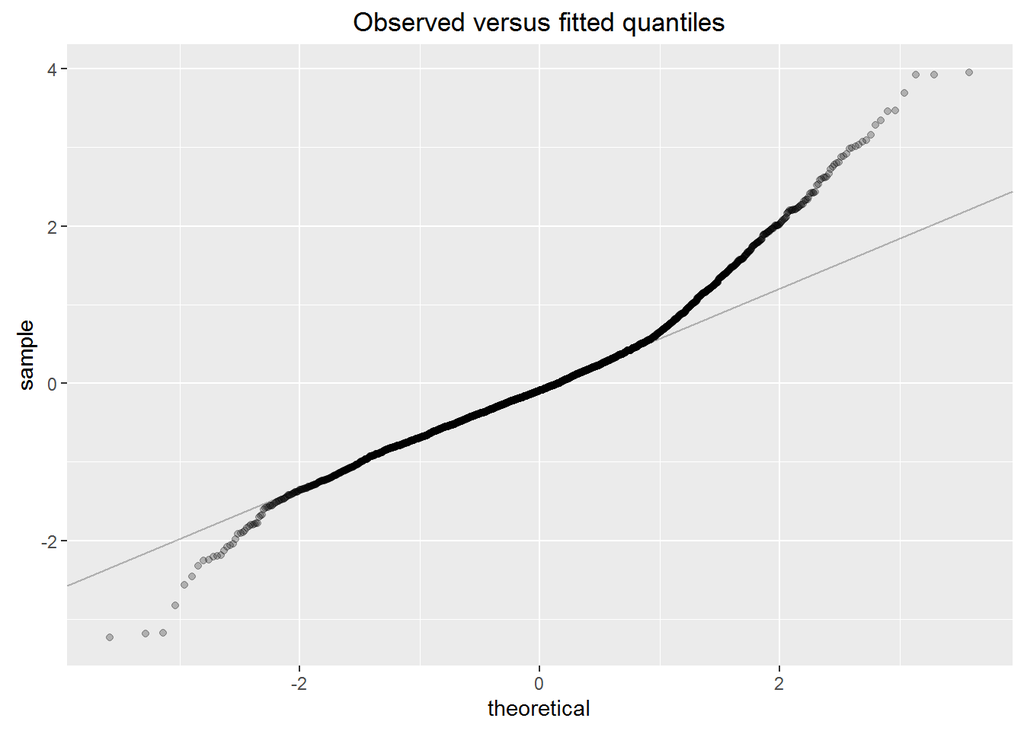

As expected, giving data is thick-tailed – at the extremes, there are both more high and low donors than expected.

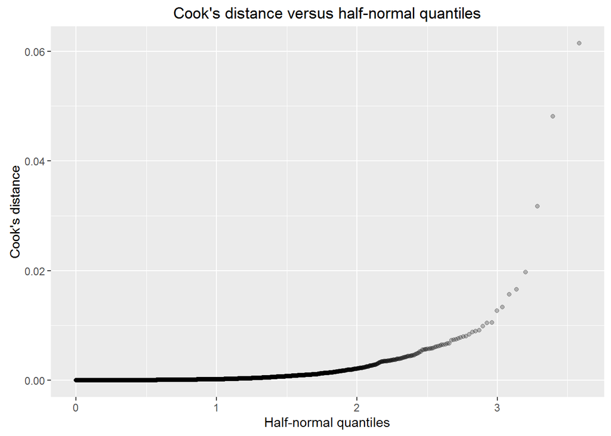

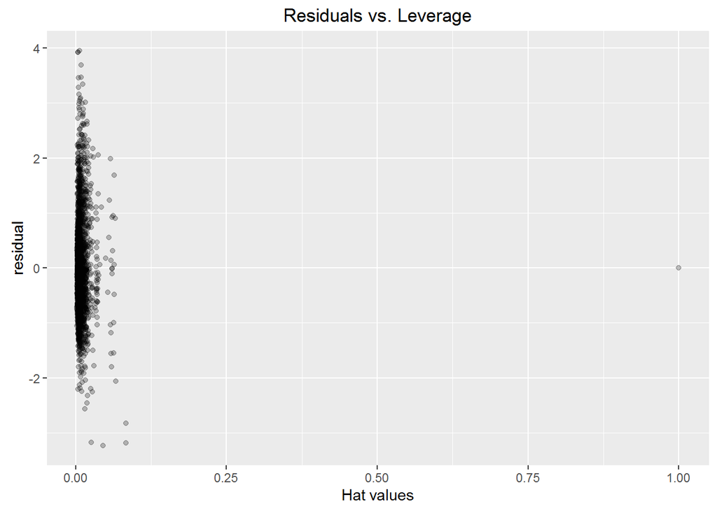

Definitely a few extreme values there…

```r
ggdat %>% arrange(cook) %>% select(rown, cook, residual, hatv) %>% tail() %>% kable(digits=3)
```

|  | rown | cook | residual | hatv |
| --- | --- | --- | --- | --- |
| 2918 | 701 | 0.016 | 1.982 | 0.058 |
| 2919 | 2012 | 0.017 | -3.172 | 0.026 |
| 2920 | 2199 | 0.020 | -2.060 | 0.066 |
| 2921 | 418 | 0.032 | -3.234 | 0.045 |
| 2922 | 1228 | 0.048 | -2.828 | 0.083 |
| 2923 | 649 | 0.061 | -3.182 | 0.084 |

```r
ggdat %>% arrange(hatv) %>% select(rown, hatv, residual, cook) %>% tail() %>% kable(digits=3)
```

|  | rown | hatv | residual | cook |
| --- | --- | --- | --- | --- |
| 2918 | 2845 | 0.064 | 0.063 | 0.000 |
| 2919 | 2643 | 0.066 | 0.898 | 0.004 |
| 2920 | 2199 | 0.066 | -2.060 | 0.020 |
| 2921 | 1228 | 0.083 | -2.828 | 0.048 |
| 2922 | 649 | 0.084 | -3.182 | 0.061 |
| 2923 | 1730 | 1.000 | 0.000 | 0.003 |

```r
summary(lmdat$deg.prg)
```

```
## Full-Time                EMBA     Other Part-Time     Ph.D.
##      1970         0       285         1       635        32
```

```r
which(lmdat$deg.prg == "Other")
```

```
## [1] 1730
```

No wonder – it’s the only `deg.prg = Other` donor. This factor should be tweaked, for example by combining the `Other` and `Ph.D.` levels.

```r
levels(lmdat$deg.prg) <- c("Full-Time", '', "EMBA", "Other", "Part-Time", "Other")
lmdat <- lmdat %>% droplevels()
```

The `leaps` package can be used to check each subset of predictors to attempt to minimize the Bayesian information criterion.

```r
library(leaps)
lm.leaps <- regsubsets(
  student.gifts.lt ~
    # Low importance
     spouse + sqrt(events.stu) + lead.facil + nice.title + sqrt(scholarship) + stu.supp +
    # Use as-is
    deg.year.ctr + deg.prg + nice.title + fys.recent + nonprofit +
    # Sqrt transform
    sqrt(employ.yrs) + sqrt(fys.giving) + sqrt(af.gifts) + sqrt(known.to) + sqrt(committees) +
    sqrt(vols) + sqrt(speak) + sqrt(stu.acts) + sqrt(events),
  data=lmdat,
  nvmax=16)
```

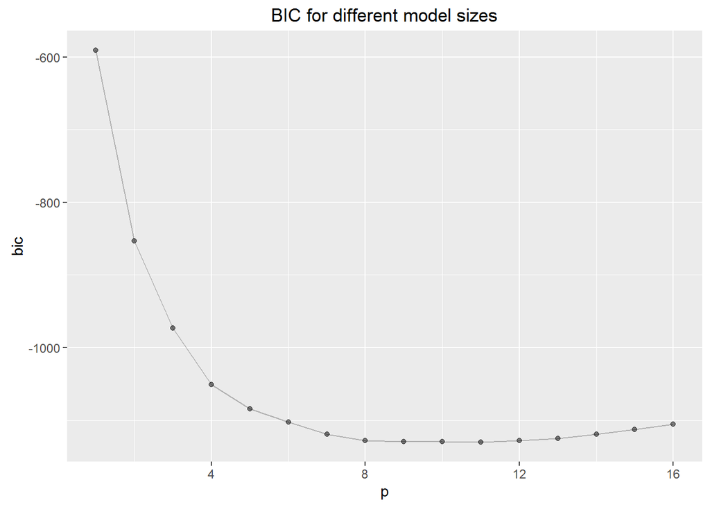

BIC is minimized by the following variables:

```r
# p minimizing BIC
(best <- which(rsubs$bic == min(rsubs$bic)))
```

```
## [1] 11
```

```r
# Best p variables (plus intercept) minimizing BIC
colnames(rsubs$which)[rsubs$which[best, ]]
```

```
##  [1] "(Intercept)"      "nice.title"       "deg.year.ctr"
##  [4] "deg.prgEMBA"      "fys.recent"       "nonprofit"
##  [7] "sqrt(employ.yrs)" "sqrt(known.to)"   "sqrt(committees)"
## [10] "sqrt(vols)"       "sqrt(speak)"      "sqrt(events)"
```

Using just these in a new model yields the following:

```r
# Trimmed dataset
lmdat2 <- lmdat %>% mutate(emba = deg.prg=="EMBA") %>% select(id, nice.title, deg.year.ctr, emba, fys.recent, nonprofit, employ.yrs, known.to, committees, vols, speak, events, student.gifts.lt)
# Trimmed model
lmod2 <- lm(
  student.gifts.lt ~
    # Use as-is
    nice.title + deg.year.ctr + emba + fys.recent + nonprofit +
    # Sqrt transform
    sqrt(employ.yrs) + sqrt(known.to) + sqrt(committees) + sqrt(vols) + sqrt(speak) + sqrt(events),
  data=lmdat2
)
```

The residual and other diagnostic plots come out about the same.

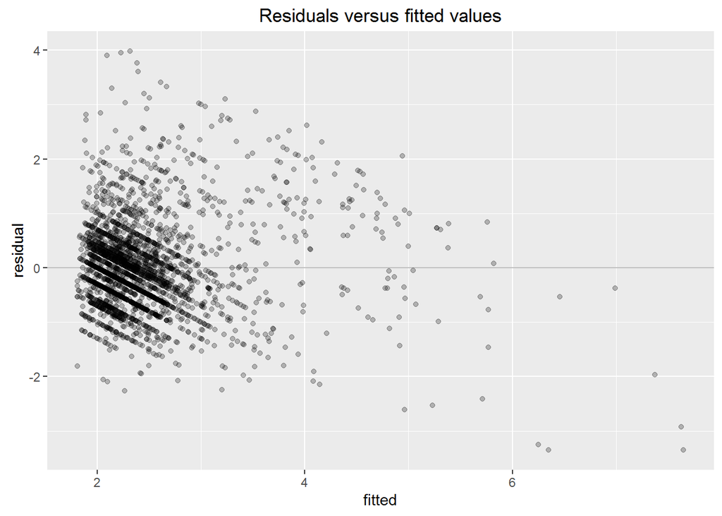

The model summary is interesting:

```
##
## Call:
## lm(formula = student.gifts.lt ~ nice.title + deg.year.ctr + emba +
##     fys.recent + nonprofit + sqrt(employ.yrs) + sqrt(known.to) +
##     sqrt(committees) + sqrt(vols) + sqrt(speak) + sqrt(events),
##     data = lmdat2)
##
## Residuals:
##     Min      1Q  Median      3Q     Max
## -3.3496 -0.4942 -0.0953  0.3659  3.9843
##
## Coefficients:
##                   Estimate Std. Error t value Pr(>|t|)
## (Intercept)       2.266555   0.064467  35.158  < 2e-16 ***
## nice.title        0.238098   0.036966   6.441 1.38e-10 ***
## deg.year.ctr     -0.006528   0.001059  -6.163 8.14e-10 ***
## embaTRUE          0.155170   0.052919   2.932 0.003392 **
## fys.recent        0.032913   0.010163   3.238 0.001216 **
## nonprofit         0.727040   0.081153   8.959  < 2e-16 ***
## sqrt(employ.yrs)  0.046940   0.009600   4.890 1.06e-06 ***
## sqrt(known.to)    0.161724   0.016983   9.523  < 2e-16 ***
## sqrt(committees)  0.638929   0.068385   9.343  < 2e-16 ***
## sqrt(vols)        0.074907   0.021713   3.450 0.000569 ***
## sqrt(speak)       0.236722   0.054129   4.373 1.27e-05 ***
## sqrt(events)      0.044333   0.013280   3.338 0.000853 ***
## ---
## Signif. codes:  0 '***' 0.001 '**' 0.01 '*' 0.05 '.' 0.1 ' ' 1
##
## Residual standard error: 0.8108 on 2911 degrees of freedom
## Multiple R-squared:  0.3426, Adjusted R-squared:  0.3401
## F-statistic: 137.9 on 11 and 2911 DF,  p-value: < 2.2e-16
```

On average, we’d guess that a donor to student causes has given about $2.27$ log dollars, or $10^2.27 = \$186$ without any other information. Younger alumni give less; all the other indicators increase giving on average.

From these variables, `nice.title`, `deg.year`, `nonprofit`, `known.to`, `committees`, and `speak` are particularly interesting as indicators because they both have relatively large coefficients and a lot of associated data.

# Prospect prioritization

From here, the simplest approach is to sort by predicted `student.gifts` within each gift capacity bin `gift.cap`.

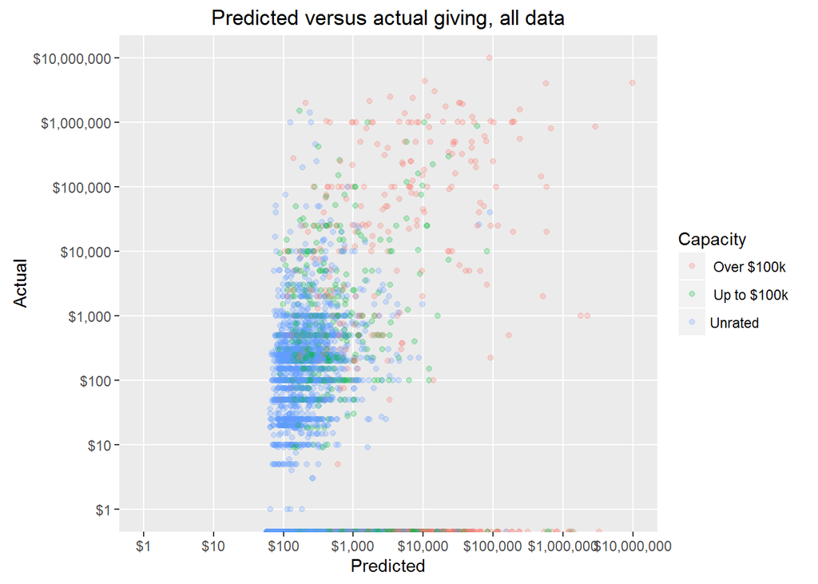

When including non-donors, the predicted amounts are biased high, unsurprisingly. The final step is to join the predictions and unique identifier and export the data. For this first pass, it’s helpful to have the data in Excel for others to explore. I’d been asked for a list of “200 to 1000 prospects” so people who have given substantially more or less than predicted are a reasonable place to start.

```r
# Save the id and prediction columns
out <- predsdat %>%
  select(id, actual = student.gifts.lt) %>%
  mutate(preds = preds, actual = ifelse(actual <= 0, 0, actual), residual = actual - preds)
```

Here’s the distribution of differences:

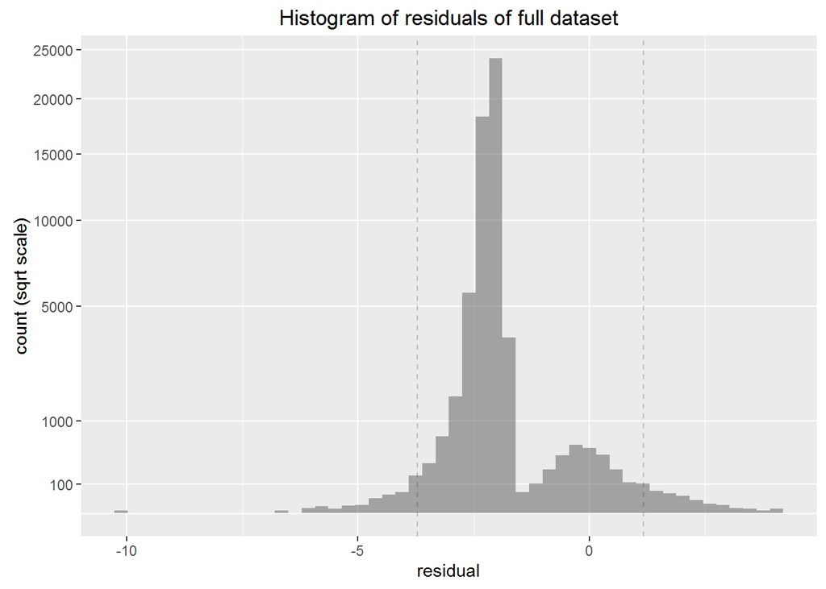

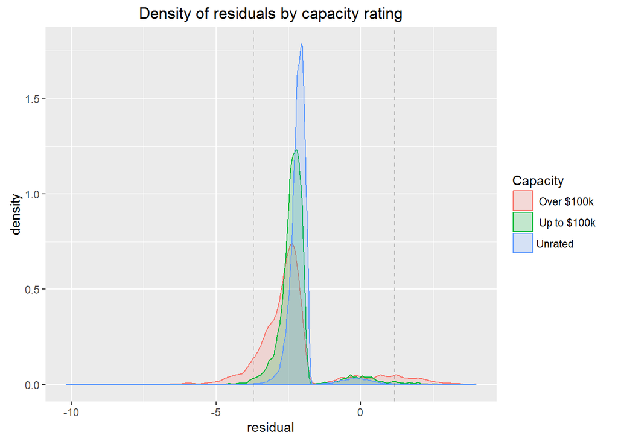

The vertical dashed lines indicate the cutoff for the 250 largest (gave more than expected) and 250 smallest (gave less than expected) residuals. Note that this is a mixture that is not even approximately centered around 0 – this follows given that these residuals include out-of-sample individuals who have never given.

This does raise a question: can I get a better model if I account for non-student support lifetime giving? Here’s the previous $r^2$:

```
## [1] 0.3425687
```

And here’s the new $r^2$ when including a term for `lt.giving` – `student.gifts`

```r
# Add lifetime giving to lmdat2
lmdat2 <- lmdat2 %>% cbind(mdat %>% filter(student.gifts > 0) %>% select(lt.giving) %>%
  # Log10 transformation
  mutate(lt.giving.lt = log(lt.giving, base=10)))
# Use same model as lmod2, adding (lt.giving) as a predictor
lmod3 <- update(lmod2, . ~ . + I(lt.giving.lt - student.gifts.lt))
summary(lmod3)
```

```
##
## Call:
## lm(formula = student.gifts.lt ~ nice.title + deg.year.ctr + emba +
##     fys.recent + nonprofit + sqrt(employ.yrs) + sqrt(known.to) +
##     sqrt(committees) + sqrt(vols) + sqrt(speak) + sqrt(events) +
##     I(lt.giving.lt - student.gifts.lt), data = lmdat2)
##
## Residuals:
##     Min      1Q  Median      3Q     Max
## -2.7899 -0.4153 -0.0495  0.3344  3.4913
##
## Coefficients:
##                                      Estimate Std. Error t value Pr(>|t|)
## (Intercept)                         3.5038950  0.0630802  55.547  < 2e-16
## nice.title                          0.1786601  0.0306121   5.836 5.93e-09
## deg.year.ctr                       -0.0208984  0.0009595 -21.781  < 2e-16
## embaTRUE                            0.1378390  0.0437647   3.150  0.00165
## fys.recent                          0.1530544  0.0090198  16.969  < 2e-16
## nonprofit                           0.6129938  0.0671825   9.124  < 2e-16
## sqrt(employ.yrs)                    0.0419035  0.0079397   5.278 1.40e-07
## sqrt(known.to)                      0.1874162  0.0140616  13.328  < 2e-16
## sqrt(committees)                    0.5378510  0.0566188   9.500  < 2e-16
## sqrt(vols)                          0.0948808  0.0179645   5.282 1.38e-07
## sqrt(speak)                         0.2067982  0.0447703   4.619 4.02e-06
## sqrt(events)                        0.0178953  0.0110056   1.626  0.10405
## I(lt.giving.lt - student.gifts.lt) -0.8771285  0.0239023 -36.696  < 2e-16
##
## (Intercept)                        ***
## nice.title                         ***
## deg.year.ctr                       ***
## embaTRUE                           **
## fys.recent                         ***
## nonprofit                          ***
## sqrt(employ.yrs)                   ***
## sqrt(known.to)                     ***
## sqrt(committees)                   ***
## sqrt(vols)                         ***
## sqrt(speak)                        ***
## sqrt(events)
## I(lt.giving.lt - student.gifts.lt) ***
## ---
## Signif. codes:  0 '***' 0.001 '**' 0.01 '*' 0.05 '.' 0.1 ' ' 1
##
## Residual standard error: 0.6705 on 2910 degrees of freedom
## Multiple R-squared:  0.5506, Adjusted R-squared:  0.5487
## F-statistic: 297.1 on 12 and 2910 DF,  p-value: < 2.2e-16
```

```r
# Save as tab-delimited text
write.table(out, file="data\\predictions.csv", sep=",", row.names=F)
```

# Future ideas

- Prediction with cross-validation
- Model including non-donors
- [Tobit model](https://en.wikipedia.org/wiki/Tobit_model) for censored data

# Packages used

```
##  setting  value
##  version  R version 3.3.0 (2016-05-03)
##  system   x86_64, mingw32
##  ui       RTerm
##  language (EN)
##  collate  English_United States.1252
##  tz       America/Chicago
##  date     2016-09-30
```

```
## Packages ------------------------------------------------------------------
```

```
##  package      * version    date       source
##  assertthat     0.1        2013-12-06 CRAN (R 3.3.0)
##  colorspace     1.2-6      2015-03-11 CRAN (R 3.3.0)
##  DBI            0.4-1      2016-05-08 CRAN (R 3.3.0)
##  devtools     * 1.12.0     2016-06-24 CRAN (R 3.3.1)
##  digest         0.6.9      2016-01-08 CRAN (R 3.3.0)
##  dplyr        * 0.5.0      2016-06-24 CRAN (R 3.3.1)
##  evaluate       0.9        2016-04-29 CRAN (R 3.3.0)
##  formatR        1.4        2016-05-09 CRAN (R 3.3.0)
##  ggplot2      * 2.1.0      2016-03-01 CRAN (R 3.3.0)
##  gtable         0.2.0      2016-02-26 CRAN (R 3.3.0)
##  highr          0.6        2016-05-09 CRAN (R 3.3.0)
##  htmltools      0.3.5      2016-03-21 CRAN (R 3.3.0)
##  knitr        * 1.13       2016-05-09 CRAN (R 3.3.0)
##  labeling       0.3        2014-08-23 CRAN (R 3.3.0)
##  lazyeval       0.1.10     2015-01-02 CRAN (R 3.3.0)
##  leaps        * 2.9        2009-05-05 CRAN (R 3.3.1)
##  lubridate    * 1.5.6      2016-04-06 CRAN (R 3.3.0)
##  magrittr       1.5        2014-11-22 CRAN (R 3.3.0)
##  memoise        1.0.0      2016-01-29 CRAN (R 3.3.0)
##  munsell        0.4.3      2016-02-13 CRAN (R 3.3.0)
##  plyr           1.8.3      2015-06-12 CRAN (R 3.3.0)
##  R6             2.1.2      2016-01-26 CRAN (R 3.3.0)
##  randomForest * 4.6-12     2015-10-07 CRAN (R 3.3.0)
##  Rcpp           0.12.4     2016-03-26 CRAN (R 3.3.0)
##  reshape2       1.4.1      2014-12-06 CRAN (R 3.3.0)
##  rmarkdown      0.9.6      2016-05-01 CRAN (R 3.3.0)
##  scales         0.4.0      2016-02-26 CRAN (R 3.3.0)
##  stringi        1.0-1      2015-10-22 CRAN (R 3.3.0)
##  stringr        1.0.0      2015-04-30 CRAN (R 3.3.0)
##  tibble         1.2        2016-08-26 CRAN (R 3.3.1)
##  withr          1.0.1      2016-02-04 CRAN (R 3.3.0)
##  wranglR      * 0.0.0.9000 2016-09-07 local
##  yaml           2.1.13     2014-06-12 CRAN (R 3.3.0)
```